# ExtraaLearn Project

1. current_occupation:
   - Distribution: Professionals form the majority, followed by Students, with a smaller proportion of Unemployed individuals.
   - Observations from graphs:
     - Stacked bar plot: Professionals exhibit the highest conversion rate, followed by Unemployed. Students have a lower conversion rate.
     - Count plot with hue: This confirms the above observation, with more converted leads (status = 1) in the Professional and Unemployed categories.
2. first_interaction:
   - Distribution: Website is the more frequent first interaction channel compared to Mobile App.
   - Observations from graphs:
     - Stacked bar plot: Both channels have huge difference in conversion rates, with Website much higher.
     - Count plot with hue: The number of converted leads is higher for those who interacted through the Website first, but this could be due to the higher overall count in this category.
3. profile_completed:
   - Distribution: 'High' completion is most frequent, followed by 'Medium' and then 'Low'.
   - Observations from graphs:
     - Stacked bar plot: Leads with 'Medium' and 'High' profile completion demonstrate significantly higher conversion rates than 'Low'.
     - Count plot with hue: This clearly shows that more conversions happen when profiles are more complete.
4. last_activity:
   - Distribution: Email Activity is most frequent, followed by Phone Activity and then Website Activity.
   - Observations from graphs:
     - Stacked bar plot: Website Activity shows the highest conversion rate, closely followed by Email Activity. Phone Activity has a lower conversion rate.
     - Count plot with hue: Supports the above observation, with more converted leads having Email Activity or Website Activity as their last activity.
5. print_media_type1, print_media_type2, digital_media, educational_channels, referral:
   - Distribution: For all these channels, 'No' (not interacted through this channel) is predominantly more frequent than 'Yes'.
   - Observations from graphs:
     - Stacked bar plots: Referrals have the highest conversion rate among these channels, followed by Print media channels and Digital Media. Educational channels show lower conversion.
     - Count plots with hue: Reinforces the above, indicating Referrals, despite being less frequent, contribute to a higher proportion of conversions.

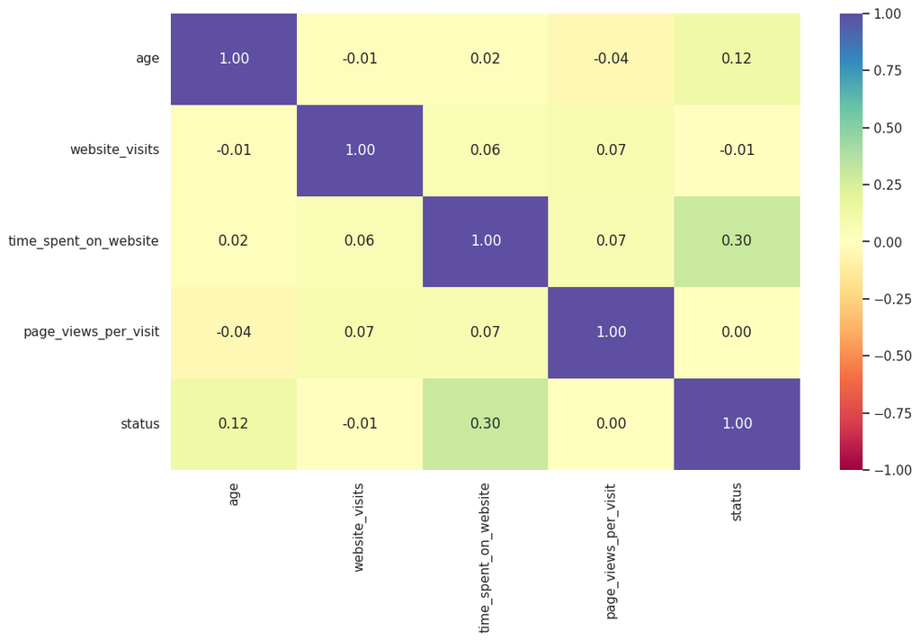

```python
plt.figure(figsize=(12, 7))
sns.heatmap(
    data[num_cols].corr(), annot=True, vmin=-1, vmax=1, fmt=".2f", cmap="Spectral"
)
plt.show()
```

## Building a Decision Tree model

```python
X = data.drop(["status"], axis=1)
Y = data.status

X = pd.get_dummies(X, drop_first=True)

X_train, X_test, y_train, y_test = train_test_split(X, Y, test_size=0.3, random_state=1, stratify = Y)
```

```python
# Scaling the data
from sklearn.preprocessing import StandardScaler
sc=StandardScaler()

# Fit_transform on train data
X_train_scaled = sc.fit_transform(X_train)
X_train_scaled = pd.DataFrame(X_train_scaled, columns=X.columns)

# Transform on test data
X_test_scaled = sc.transform(X_test)
X_test_scaled = pd.DataFrame(X_test_scaled, columns=X.columns)
```

```python
# Creating metric function
def metrics_score(actual, predicted):
    print(classification_report(actual, predicted))

    cm = confusion_matrix(actual, predicted)
    plt.figure(figsize=(8,5))

    sns.heatmap(cm, annot=True,  fmt='.2f',  xticklabels = ['Not Converted', 'Converted'], yticklabels = ['Not Converted', 'Converted'])
    plt.ylabel('Actual')
    plt.xlabel('Predicted')
    plt.show()
```

```python
model_dt = DecisionTreeClassifier(random_state=1)
model_dt.fit(X_train_scaled, y_train)
```

```
DecisionTreeClassifier(random_state=1)
```

```
              precision    recall  f1-score   support

           0       1.00      1.00      1.00      2264
           1       1.00      1.00      1.00       964

    accuracy                           1.00      3228
   macro avg       1.00      1.00      1.00      3228
weighted avg       1.00      1.00      1.00      3228
```

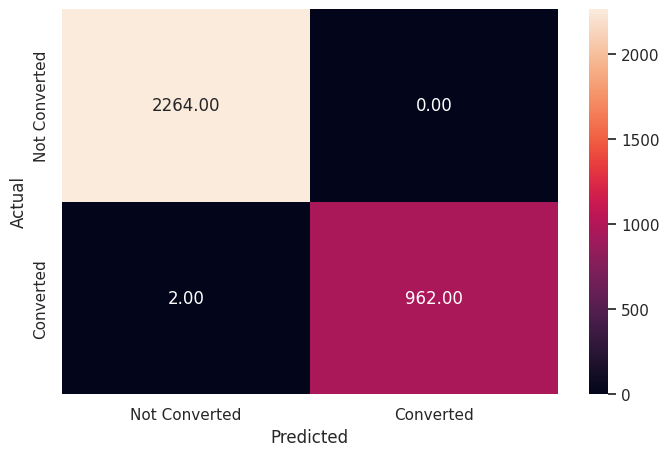

```python
pred_train_dt = model_dt.predict(X_train_scaled)
metrics_score(y_train, pred_train_dt)
```

```
              precision    recall  f1-score   support

           0       0.86      0.87      0.87       971
           1       0.69      0.67      0.68       413

    accuracy                           0.81      1384
   macro avg       0.78      0.77      0.77      1384
weighted avg       0.81      0.81      0.81      1384
```

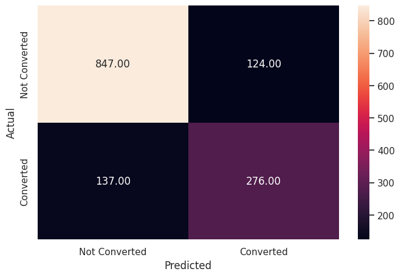

```python
pred_test_dt = model_dt.predict(X_test_scaled)
metrics_score(y_test, pred_test_dt)
```

The Decision Tree works well on the training data but not so well on the test data as the recall is 0.67 in comparison to 1 for the training dataset, i.e., the Decision Tree is overfitting the training data.

The precision on the test data suggests that there is a 69% of the leads the model predicted to convert were actually converted. The model correctly classified 81% of all the leads in the test set.

**Perform hyperparameter tuning for the decision tree model using GridSearch CV**

```python
# Choose the type of classifier
model_dt_tuned = DecisionTreeClassifier(random_state = 7, class_weight = {0: 0.3, 1: 0.7})

# Grid of parameters to choose from
parameters = {
    # "max_depth": np.arange(1, 10),
    "max_depth": np.arange(1,100,10),
    "max_leaf_nodes": [5, 10, 15, 20],
    "min_samples_split": [70, 100]
             }

# Type of scoring used to compare parameter combinations - recall score for class 1
scorer = metrics.make_scorer(recall_score, pos_label = 1)

# Run the grid search
grid_obj = GridSearchCV(model_dt_tuned, parameters, scoring = scorer, cv = 5)
grid_obj = grid_obj.fit(X_train_scaled, y_train)

# Set the classifier to the best combination of parameters
model_dt_tuned = grid_obj.best_estimator_

# Fit the best algorithm to the data
model_dt_tuned.fit(X_train_scaled, y_train)
```

```
DecisionTreeClassifier(class_weight={0: 0.3, 1: 0.7}, max_depth=np.int64(11),
                       max_leaf_nodes=10, min_samples_split=70, random_state=7)
```

```
              precision    recall  f1-score   support

           0       0.94      0.81      0.87      2264
           1       0.66      0.89      0.76       964

    accuracy                           0.83      3228
   macro avg       0.80      0.85      0.81      3228
weighted avg       0.86      0.83      0.84      3228
```

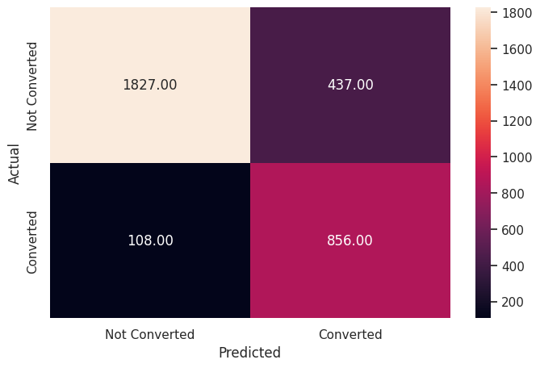

```python
pred_train_dt2 = model_dt_tuned.predict(X_train_scaled)
metrics_score(y_train, pred_train_dt2)
```

```
              precision    recall  f1-score   support

           0       0.93      0.80      0.86       971
           1       0.65      0.85      0.74       413

    accuracy                           0.82      1384
   macro avg       0.79      0.83      0.80      1384
weighted avg       0.84      0.82      0.82      1384
```

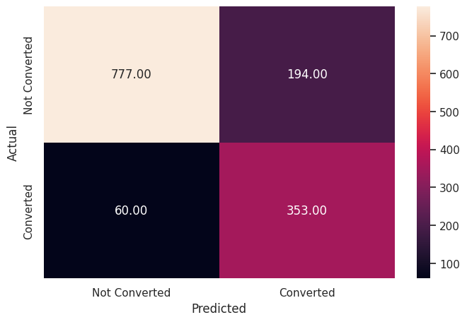

```python
pred_test_dt2 = model_dt_tuned.predict(X_test_scaled)
metrics_score(y_test, pred_test_dt2)
```

Tuned model has provided a generalised performance with balanced precision and recall values. However, there is a little bit of overfitting, and model performance on test data has slightly improved.

## Do we need to prune the tree?

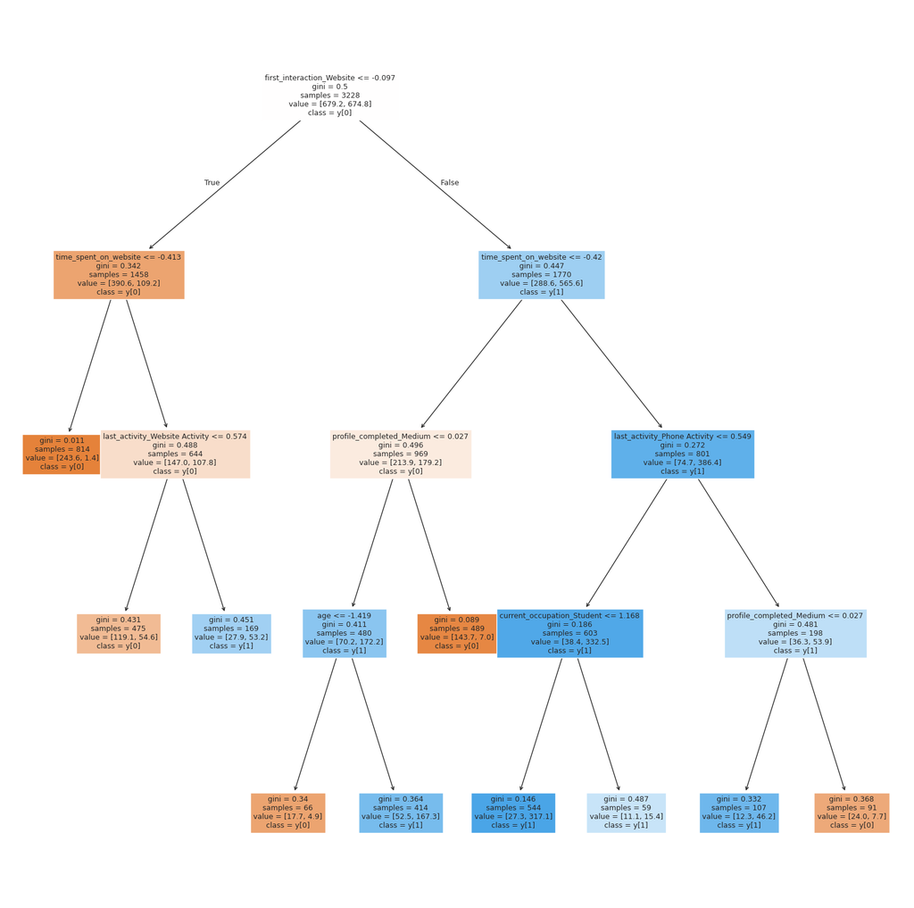

```python
features = list(X.columns)

plt.figure(figsize = (20, 20))

tree.plot_tree(model_dt_tuned, feature_names = features, filled = True, fontsize = 9, node_ids = False, class_names = True)

plt.show()
```

Note: Blue leaves represent the converted leads, i.e., y[1], while the orange leaves represent the not converted leads, i.e., y[0]. Also, the more the number of observations in a leaf, the darker its color gets.

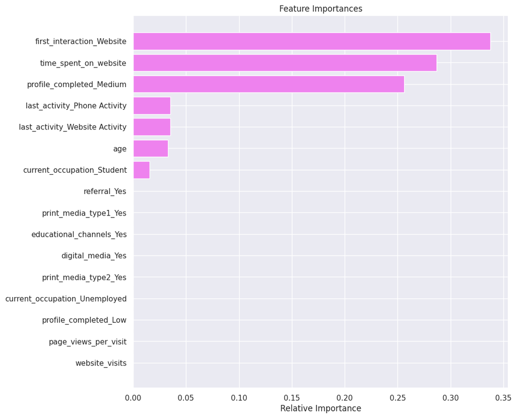

```python
# Plotting the feature importance
importances = model_dt_tuned.feature_importances_
indices = np.argsort(importances)

plt.figure(figsize = (10, 10))
plt.title('Feature Importances')
plt.barh(range(len(indices)), importances[indices], color = 'violet', align = 'center')
plt.yticks(range(len(indices)), [features[i] for i in indices])
plt.xlabel('Relative Importance')
plt.show()
```

The decision tree model reveals that first_interaction_website and time spent on the website are the most important features followed by profile_completed, age, last_activity, and current occupation. In this model, the remaining variables are not significant factors in determining whether a lead will convert.

It is beneficial to prune the tree to improve the performance of the decision tree model and avoid overfitting.

## Building a Random Forest model

```python
rf_estimator = RandomForestClassifier(random_state = 1)
rf_estimator.fit(X_train, y_train)
```

```
RandomForestClassifier(random_state=1)
```

```
              precision    recall  f1-score   support

           0       1.00      1.00      1.00      2264
           1       1.00      1.00      1.00       964

    accuracy                           1.00      3228
   macro avg       1.00      1.00      1.00      3228
weighted avg       1.00      1.00      1.00      3228
```

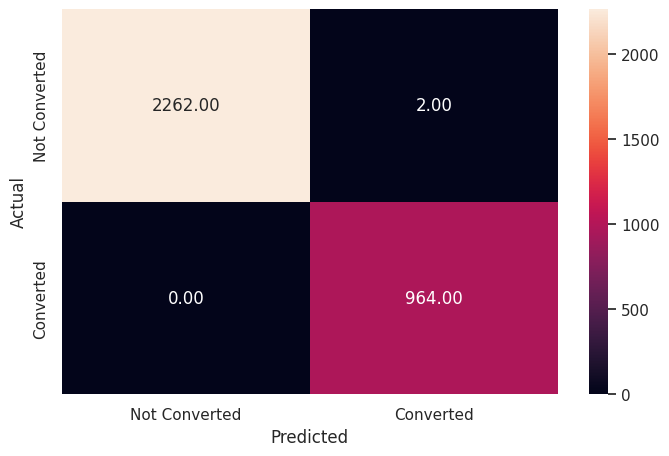

```python
pred_train_rf = rf_estimator.predict(X_train)
metrics_score(y_train, pred_train_rf)
```

Close to 0 errors on the training set. Model has performed very well on the training set.

```
              precision    recall  f1-score   support

           0       0.89      0.91      0.90       971
           1       0.78      0.73      0.76       413

    accuracy                           0.86      1384
   macro avg       0.83      0.82      0.83      1384
weighted avg       0.86      0.86      0.86      1384
```

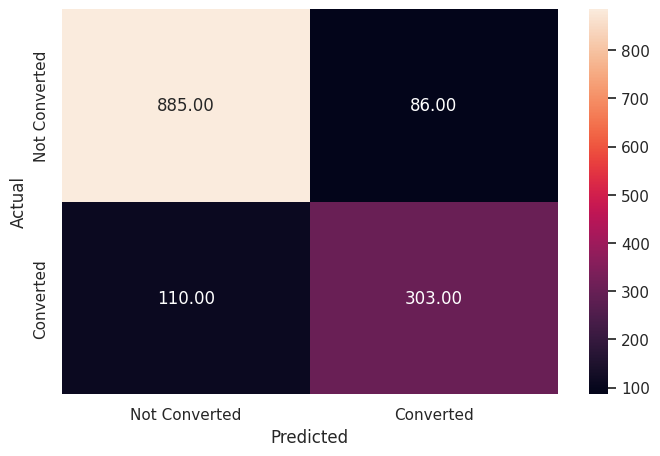

```python
pred_test_rf = rf_estimator.predict(X_test)
metrics_score(y_test, pred_test_rf)
```

The Random Forest classifier seems to be overfitting. The recall score is 0.73. Need to reduce overfitting and improve recall by hyperparameter tuning.

## Do we need to prune the tree?

```python
rf_estimator_tuned = RandomForestClassifier(criterion = "entropy", random_state = 7)

# Grid of parameters to choose from
parameters2 = {
    "n_estimators": [700, 250, 500],
    "max_features": [0.7, 'auto'],
    "max_samples": [0.9, 1],
    "max_leaf_nodes": [5, 10, 15, 20],
             }

# Type of scoring used to compare parameter combinations - recall score for class 1
scorer2 = metrics.make_scorer(recall_score, pos_label = 1)

# Run the grid search on the training data using scorer=scorer and cv=5
grid_obj2 = GridSearchCV(rf_estimator_tuned, parameters2, scoring = scorer2, cv = 5)
grid_obj2 = grid_obj2.fit(X_train, y_train)

rf_estimator_tuned = grid_obj2.best_estimator_
rf_estimator_tuned.fit(X_train, y_train)
```

```
RandomForestClassifier(criterion='entropy', max_features=0.7, max_leaf_nodes=10,
                       max_samples=0.9, n_estimators=500, random_state=7)
```

```
              precision    recall  f1-score   support

           0       0.88      0.92      0.90      2264
           1       0.79      0.71      0.75       964

    accuracy                           0.86      3228
   macro avg       0.83      0.82      0.82      3228
weighted avg       0.85      0.86      0.85      3228
```

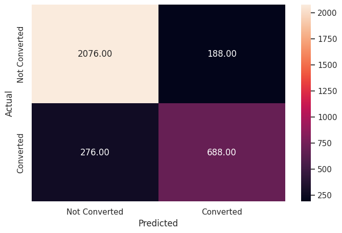

```python
pred_train_rf2 = rf_estimator_tuned.predict(X_train)
metrics_score(y_train, pred_train_rf2)
```

```
              precision    recall  f1-score   support

           0       0.88      0.93      0.91       971
           1       0.81      0.71      0.76       413

    accuracy                           0.86      1384
   macro avg       0.85      0.82      0.83      1384
weighted avg       0.86      0.86      0.86      1384
```

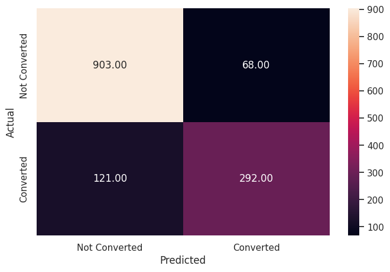

```python
pred_test_rf2 = rf_estimator_tuned.predict(X_test)
metrics_score(y_test, pred_test_rf2)
```

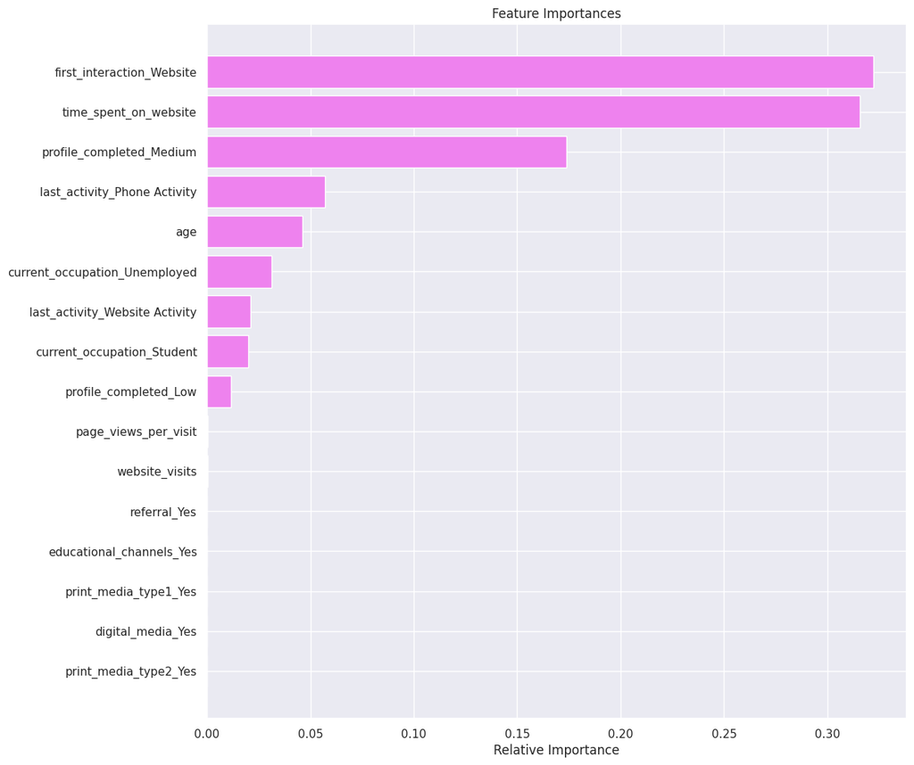

```python
importances = rf_estimator_tuned.feature_importances_
indices = np.argsort(importances)

feature_names = list(X.columns)
plt.figure(figsize = (12, 12))
plt.title('Feature Importances')
plt.barh(range(len(indices)), importances[indices], color = 'violet', align = 'center')
plt.yticks(range(len(indices)), [feature_names[i] for i in indices])
plt.xlabel('Relative Importance')
plt.show()
```

Similar to the decision tree model, first_interaction_website and time spent on the website are the most important features followed by profile_completed, age, last_activity, and current occupation.

The random forest gives some importance to other variables like current_occupation_unemployed, current_occupation_Student, as well. It gives importance to more factors in comparison to the decision tree.

## Actionable Insights and Recommendations

**Conclusion:**

1. Current Occupation

Professionals form the majority of leads and have the highest conversion rate.

Unemployed individuals show a surprisingly decent conversion rate despite lower volume.

Students are numerous but convert at a lower rate.

2. First Interaction

Most leads come from the Website, and this channel shows a significantly higher conversion rate than the Mobile App.

Website users tend to be more engaged and informed.

3. Profile Completion

Leads with Medium or High profile completion have much higher conversion rates, indicating stronger intent and engagement.

Low completion correlates with poor conversion.

4. Last Activity

Email is the most frequent last interaction, but Website Activity (like live chat or profile updates) has the highest conversion rate.

Phone-based interactions have lower success.

5. Marketing Channels

Most leads don’t come from external media, but:

Referrals yield the highest conversion rates.

Print and digital media also show good performance despite low volume.

Educational channels underperform.

7. Feature Importance (ML Models)

Top predictive features from Decision Tree and Random Forest:

first_interaction_website

time_spent_on_website

profile_completed

age

last_activity

current_occupation

Random Forest shows more nuanced feature importance than the Decision Tree.

**Business Recommendations:**

1. Lead Prioritization

Prioritize Professionals and Unemployed leads (especially those engaging via Website).

2. Channel Strategy

Invest more in the Website channel and optimize the Mobile App to reduce the conversion gap.

Double down on Referral Programs — they convert well even if lead volume is low.

Monitor print and digital media campaigns carefully — though less common, they have potential.

3. Profile Completion Campaign

Encourage users to complete their profiles by:

- Offering small rewards or unlockable content.
- Improving form UX and progress visibility.
- Sending reminders or tips via email.
4. Communication Optimization

Continue focusing on Email nurturing, but combine it with website-based nudges like live chat or interactive content.

Reduce reliance on phone-based outreach unless combined with more personalized or urgent messaging.

5. Analytics & Automation

Use the machine learning model to score and rank leads daily based on conversion probability.

Focus human resources (sales reps) on top-scoring leads with high engagement metrics.